# Análise dos convênios do Fundo Nacional Antidrogas

2018

## Introdução/Objetivo:

A fim de aprimorar a gestão dos convênios entre o Fundo Nacional Antidrogas - FUNAD e os diversos tipos de convenientes, a Secretaria Nacional Antidrogas - SENAD desenvolveu um relatório de acompanhamento, chamando "ListaConvênioGrupo". O principal objetivo deste estudo é verificar se existe alguma consistência na relação entre o total de convênios e os valores de repasse por unidade da federação.

## Contexto (Justificativa):

O FNAD recebe recursos tanto do Orçamento Nacional(maior parte dos recursos), quanto de emendas parlamentares impositivas, estas sem qualquer gerência por parte da SENAD. Todos oss projeto, independentes da origem dos recursos, devem estar de acordo com o Plano Nacional Antidrogas.

## Método:

O relatório "ListaConvênioGrupo" é o resultado da junção de diversas bases do SICONV: siconv_convenio, siconv_desembolso, siconv_proposta e siconv_pagamento. Além destas, uma outra tabela é utilizada, DAP, com as informações da Diretoria de Articulação e Projetos - DAP. Para isso foi utilizado o comando "left_join". Porém, para evitar distorções, foram excluídos os convênios de 2018, pois no Siconv constam propostas ainda em análise que podem não ser efetivadas e com isso gerar um total irrealista.

## Convênio por UF - Período 2008 - 2017

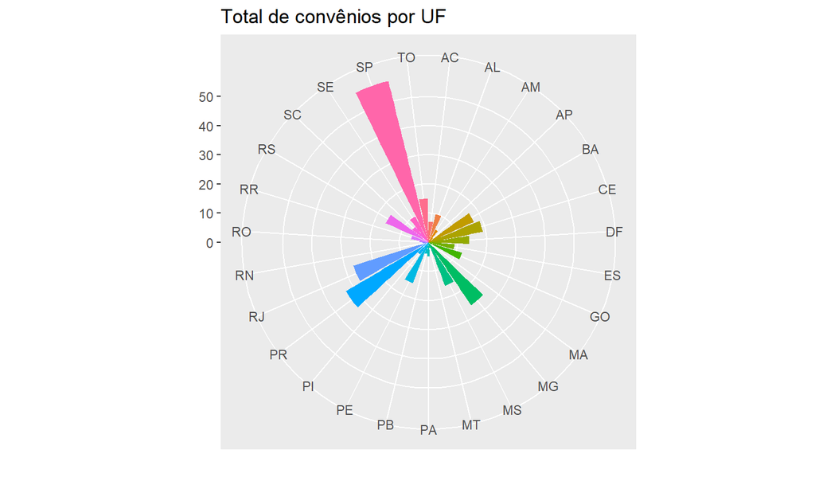

## Convênio por UF e Ano - Período 2008-2017

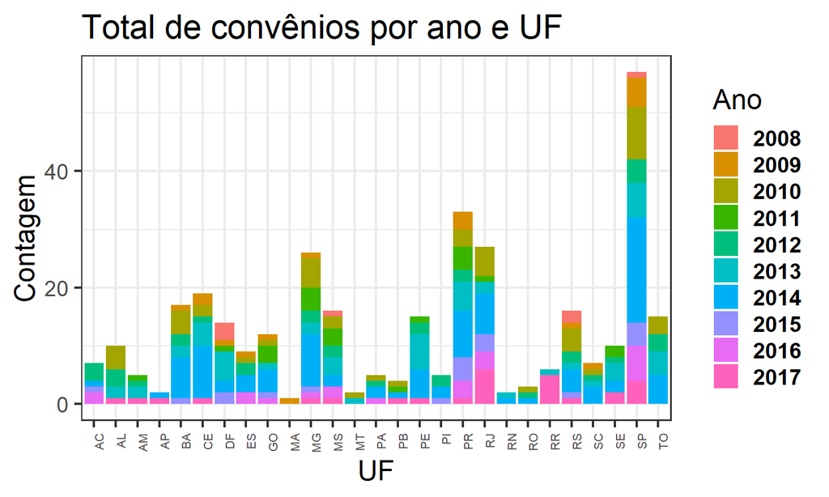